# MTH6139 Time Series - Coursework 1: Airline Passenger Forecasting

Daniel Abdullaj

Spring term 2025

# Introduction

Working in World Duty Free at Heathrow Airport, I’m constantly surrounded by the flow of passengers coming and going from all over the world. It’s made me more aware of how air travel changes over time, especially during busy seasons when the airport feels completely different compared to quieter periods.

Because of this I chose to analyse a dataset that tracks monthly airline passenger numbers. It’s interesting to see whether the patterns I notice in real life, like peak travel periods and overall growth, actually show up in the data.

The aim of this project is to explore how passenger numbers have evolved over time and to use Meta’s Prophet model to forecast future trends. By doing this I hope to better understand both the long-term growth of air travel and the seasonal patterns that drive it.

## Getting the data ready

The dataset is stored as a CSV file within the project folder. It is first loaded into R so that its structure and contents can be checked before any analysis is carried out.

```r
air_data <- read.csv("data/air_passengers_prophet.csv")
head(air_data)
```

```
##           ds   y
## 1 1949-01-01 112
## 2 1949-02-01 118
## 3 1949-03-01 132
## 4 1949-04-01 129
## 5 1949-05-01 121
## 6 1949-06-01 135
```

```r
str(air_data)
```

```
## 'data.frame':    144 obs. of  2 variables:
##  $ ds: chr  "1949-01-01" "1949-02-01" "1949-03-01" "1949-04-01" ...
##  $ y : int  112 118 132 129 121 135 148 148 136 119 ...
```

From this it can be seen that the dataset contains two main columns: one representing the date and the other representing the number of passengers. The structure is already quite clean but the date column needs to be converted into a proper date format.

To ensure compatibility with Prophet the date column is converted into a standard date format.

```r
air_data$ds <- as.Date(air_data$ds)
```

The dataset is now in the correct format required by Prophet, with `ds` representing dates and `y` representing the observed values. This means it is ready for further analysis.

# Exploring the Data

Before building a forecasting model, it is important to understand how the data behaves over time. A time series plot provides a clear overview of any trends or recurring patterns.

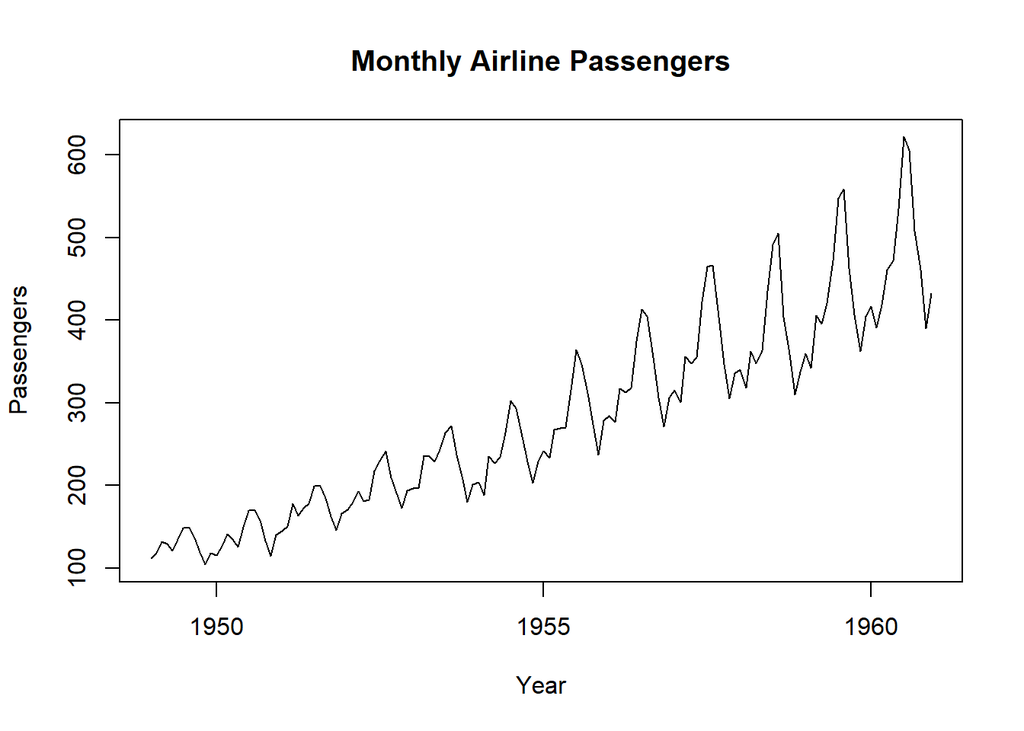

```r
plot(air_data$ds, air_data$y, type = "l",
     main = "Monthly Airline Passengers",
     xlab = "Year", ylab = "Passengers")
```

The plot shows a clear upward trend indicating that passenger numbers have increased steadily over time. There is also a noticeable seasonal pattern with regular peaks and dips each year.

In addition the fluctuations appear to grow larger as time goes on suggesting that variability increases alongside the overall level of the series.

To gain a better understanding of how the values are distributed a histogram can also be useful.

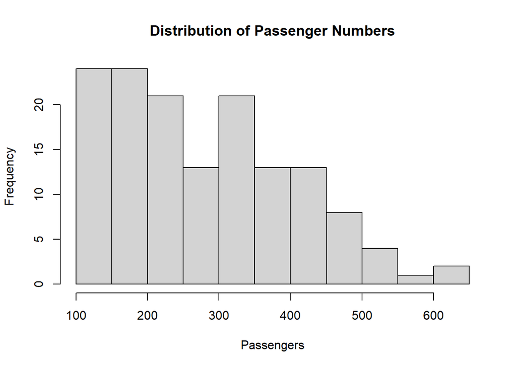

```r
hist(air_data$y,
     main = "Distribution of Passenger Numbers",
     xlab = "Passengers")
```

# Forecasting with Prophet

To model the time series, Meta’s Prophet forecasting tool is used. This model is particularly suitable for data that contains both trend and seasonality.

The model is fitted using the prepared dataset.

```r
library(prophet)

air_model <- prophet(air_data)
```

The model automatically identifies the underlying trend and seasonal patterns present in the data, which are then used to generate forecasts.

# Producing the Forecast

Once the model has been fitted, future dates are created in order to extend the time series beyond the observed data.

```r
future_dates <- make_future_dataframe(air_model, periods = 24, freq = "month")
forecast <- predict(air_model, future_dates)
```

This step allows the model to produce forecasts for the next two years, based on the patterns it has learned from the historical data.

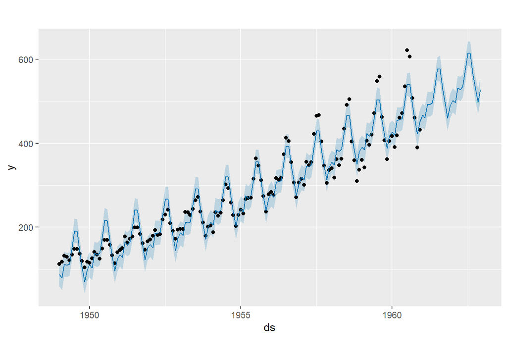

```r
plot(air_model, forecast)
```

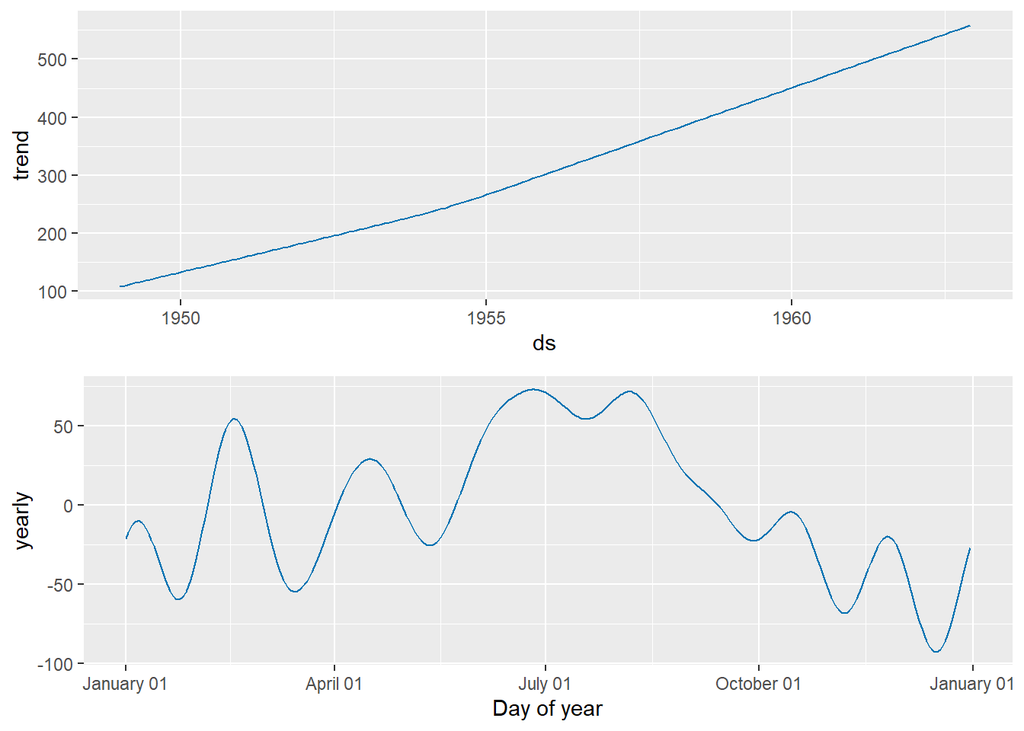

```r
prophet::prophet_plot_components(air_model, forecast)
```

The forecast suggests that passenger numbers will continue to increase, following the existing upward trend. The seasonal pattern remains consistent with regular peaks and dips each year.

Overall the model appears to capture the main features of the data and provides a reasonable projection of future values.

The components plot breaks the forecast into its main elements, including the overall trend and seasonal effects.

It shows that the upward trend is the dominant feature of the series, while the seasonal component captures the regular fluctuations observed each year.

# Conclusion

In this project, airline passenger data was analysed to identify key trends and patterns over time. The data showed a clear upward trend along with strong seasonal behaviour.

Using Prophet, a forecasting model was built that successfully captured these patterns and produced plausible future estimates. This demonstrates how time series models can be used to understand and predict real-world behaviour in areas such as air travel.

## References

Meta (2023). *Prophet: Forecasting at scale*. Available at: https://facebook.github.io/prophet/docs/quick_start.html (Accessed: 18 March 2026).

Hyndman, R.J. and Athanasopoulos, G. (2021). *Forecasting: Principles and Practice*. 3rd edn. Available at: https://otexts.com/fpp3/ (Accessed: 18 March 2026).

Box, G.E.P., Jenkins, G.M. and Reinsel, G.C. (2015). *Time Series Analysis: Forecasting and Control*. 5th edn. Wiley.

R Core Team (2025). *R: A language and environment for statistical computing*. Vienna: R Foundation for Statistical Computing. Available at: https://www.r-project.org/ (Accessed: 18 March 2026).

R Core Team (2025). *AirPassengers dataset*. Available within the datasets package in R.